# Python Pandas Tutorial

## Pandas

### Pandas is an open-source, BSD-licensed Python library providing high-performance, easy-to-use data structures and data analysis tools for the Python programming language. Python with Pandas is used in a wide range of fields including academic and commercial domains including finance, economics, Statistics, analytics, etc.

### Key features of pandas

#### 1.Fast and efficient DataFrame object with default and customized indexing.

#### 2.Tools for loading data into in-memory data objects from different file formats.

#### 3.Data alignment and integrated handling of missing data.

#### 4.Reshaping and pivoting of date sets.

#### 5.Label-based slicing, indexing and subsetting of large data sets.

#### 6.Columns from a data structure can be deleted or inserted.

#### 7.Group by data for aggregation and transformations.

#### 8.High performance merging and joining of data.

#### 9.Time Series functionality.

### Pandas deals with the following three data structures −

### 1.Series

##### Series is a one-dimensional array like structure with homogeneous data.

### 2.DataFrame

##### DataFrame is a two-dimensional array with heterogeneous data.

### 3.Panel

##### Panel is a three-dimensional data structure with heterogeneous data. It is hard to represent the panel in graphical representation. But a panel can be illustrated as a container of DataFrame.

```python
#An example to demonstrate creation of empty series in pandas.

import pandas as pd  #importing pandas library and naming it as pd
a = pd.Series()
print(a)
```

```
Series([], dtype: float64)
```

### Explanation

#### In the above example we imported pandas library as pd and then created empty series using pandas and same is given as output

```python
#An example to demonstrate creation of  series in pandas using np

import pandas as pd #importing pandas library and naming it as pd
import numpy as np  #importing numpy library and naming it as np
data = np.array(['red','black','blue','green'])
a = pd.Series(data)
print(a)
```

```
0      red
1    black
2     blue
3    green
dtype: object
```

### Explanation

#### In the above example we have imported both pandas and numpy libraries and created a array using np.array() and then used the same array to creat series using pandas and same is given as output

```python
#An example to demonstrate creation of  series as well as indexes in pandas using np

import pandas as pd #importing pandas library and naming it as pd
import numpy as np  #importing numpy library and naming it as np
data = np.array(['red','black','blue','green'])
a = pd.Series(data,index=[101,102,103,104])
print(a)
```

```
101      red
102    black
103     blue
104    green
dtype: object
```

### Explanation

#### In the above example we have imported both pandas and numpy libraries and created a array using np.array() and then used the same array and we have also given our own indexes to create series using pandas and same is given as output.

```python
#An example to demonstrate creation of  series using dicts in pandas using np

import pandas as pd #importing pandas library and naming it as pd
import numpy as np  #importing numpy library and naming it as np
data = {'red': 1 ,'black' : 2,'blue': 3,'green': 4}
a = pd.Series(data)
print(a)
```

```
red      1
black    2
blue     3
green    4
dtype: int64
```

### Explanation

#### In the above example we have imported both pandas and numpy libraries and created a dictionary and then used the same dictionary to create series using pandas and same is given as output.

```python
#An example to demonstrate creation of  series using dicts and also retrieval elements in pandas using np

import pandas as pd #importing pandas library and naming it as pd
import numpy as np  #importing numpy library and naming it as np
data = {'r': 11 ,'b' : 12,'c': 13,'g': 14}
a = pd.Series(data)
print(a[2]) #prints only the value stored in position [2]
print(a[:2]) #prints all the value stored before position [2]
print(a[2:]) #prints all the value stored after position [2]

print(a['b']) #retrieves single  element with index b
print(a[['r','g','c']]) #retrieves multiple elements
```

```
13
r    11
b    12
dtype: int64
c    13
g    14
dtype: int64
12
r    11
g    14
c    13
dtype: int64
```

### Explanation

#### In the above example we have imported both pandas and numpy libraries and created a dictionary and then used the same dictionary to create series using pandas and we have printed the results using indexes and values which are specified line by line and same is given as output.

```python
#An example to demonstrate creation of  DataFrame

import pandas as pd
data = [['Arya',16],['Jon',23],['Sansa',20],['Rob',25]]
df = pd.DataFrame(data,columns=['Name','Age']) #column name
print(df)
```

```
    Name  Age
0   Arya   16
1    Jon   23
2  Sansa   20
3    Rob   25
```

### Explanation

#### In the above example we have demonstarted the creation of DataFrame using pd.DataFrame(). we have also specified the column names and same is given as the output.

```python
#An example to demonstrate creation of  DataFrame with specified indexes.

import pandas as pd
data = [['Arya',16],['Jon',23],['Sansa',20],['Rob',25]]
df = pd.DataFrame(data,columns=['Name','Age'],index = ['stark1','stark2','stark3','stark4']) #column name and indexes
print(df)
```

```
         Name  Age
stark1   Arya   16
stark2    Jon   23
stark3  Sansa   20
stark4    Rob   25
```

### Explanation

#### In the above example we have demonstarted the creation of DataFrame using pd.DataFrame(). we have also specified the column names along with indexes and same is given as the output.

```python
#An example to demonstrate creation of DataFrame using list and Dicts.

import pandas as pd
data = [{'Name': 'Arya', 'age': 16},{'Name': 'Jon', 'age': 23},{'Name': 'Sansa', 'age': 20},{'Name': 'Rob', 'age': 25}] #creation of dict
df = pd.DataFrame(data,index=['stark1','stark2','stark3','stark4']) #index names
print(df)
```

```
         Name  age
stark1   Arya   16
stark2    Jon   23
stark3  Sansa   20
stark4    Rob   25
```

### Explanation

#### In the above example we have demonstarted the creation of DataFrame by creating a dict and list, we have also specified the column names along with indexes and same is given as the output.

```python
#An example to demonstrate creation of DataFrame using series.

import pandas as pd

d = {'Name' : pd.Series(['Arya','jon','Sansa','Rob'], index=['stark1','stark2','stark3','stark4']), #creation of series
   'Age' : pd.Series([16, 23, 20, 25], index=['stark1','stark2','stark3','stark4'])}

df = pd.DataFrame(d)
print(df)
print("****************")
print(df['Name']) #prints only one column i.e Name
```

```
         Name  Age
stark1   Arya   16
stark2    jon   23
stark3  Sansa   20
stark4    Rob   25
****************
stark1     Arya
stark2      jon
stark3    Sansa
stark4      Rob
Name: Name, dtype: object
```

### Explanation

#### n the above example we have demonstarted the creation of DataFrame by creating series, we have also specified the column names along with indexes and same is given as the output.

```python
#An example to demonstrate additon of new column and deletion function in  DataFrame using series.

import pandas as pd

d = {'Name' : pd.Series(['Arya','jon','Sansa','Rob'], index=['stark1','stark2','stark3','stark4']), #creation of series
   'Age' : pd.Series([16, 23, 20, 25], index=['stark1','stark2','stark3','stark4'])}

df = pd.DataFrame(d)
print(df)
print("***DataFrame after addition of new column***")

df['Rating']=pd.Series([5,4,3,2], index=['stark1','stark2','stark3','stark4']) #addition of new columns Rating
print(df)

print("***DataFrame after deletion of age column***")
del df['Age'] #deleting the column age
print(df)
```

```
         Name  Age
stark1   Arya   16
stark2    jon   23
stark3  Sansa   20
stark4    Rob   25
***DataFrame after addition of new column***
         Name  Age  Rating
stark1   Arya   16       5
stark2    jon   23       4
stark3  Sansa   20       3
stark4    Rob   25       2
***DataFrame after deletion of age column***
         Name  Rating
stark1   Arya       5
stark2    jon       4
stark3  Sansa       3
stark4    Rob       2
```

### EXplanation

#### In the above Example we have demonstrated the addition of new column to existing data frame, we have added the new column Rating to the DataFrame and then used del() function to delete Age column.

```python
#An Example to demonstrate creation of empty panel in Pandas

import pandas as pd
p = pd.Panel()
print(p)
```

[output not shown]

### Explanation

#### In the above example we have demonstrated the creation panels using pd.panel() in pandas

```python
#An example to demonstrate creation of  DataFrame

import pandas as pd
import numpy as np
data = {'p1' : pd.DataFrame(np.arange(5)),
   'p2' : pd.DataFrame(np.arange(4))}
exmp = pd.Panel(data)
print(exmp['p2'])
```

```
     0
0  0.0
1  1.0
2  2.0
3  3.0
4  NaN
```

### Explanation

#### In the above example we have demonstrated the creation of panel, we have first created a DataFrame using np.arange() and then created a panel and same is given as output

```python
#An example to demonstrate some basic pandas functions.

import pandas as pd
import numpy as np
data = {'p1' : pd.DataFrame(np.arange(12))}
exmp = pd.Panel(data)
print(exmp)
print("***The axes of the data are:***") #The function .axes give the axes of the object
print(exmp.axes)
print("***Is the object empty ?***") #The function .empty check if the object is empty and gives result as TRUE or FALSE
print(exmp.empty)
print("***The dimensions of the object:***") #The function .ndim gives the dimension of the object.
print(exmp.ndim)
print ("***The size of the object:***") #The function .size gives the size of the object
print(exmp.size)
print("***The values of the object are :***") #The function .values gives the values of the object
print(exmp.values)
```

```
<class 'pandas.core.panel.Panel'>
Dimensions: 1 (items) x 12 (major_axis) x 1 (minor_axis)
Items axis: p1 to p1
Major_axis axis: 0 to 11
Minor_axis axis: 0 to 0
***The axes of the data are:***
[Index(['p1'], dtype='object'), RangeIndex(start=0, stop=12, step=1), RangeIndex(start=0, stop=1, step=1)]
***Is the object empty ?***
False
***The dimensions of the object:***
3
***The size of the object:***
12
***The values of the object are :***
[[[ 0]
  [ 1]
  [ 2]
  [ 3]
  [ 4]
  [ 5]
  [ 6]
  [ 7]
  [ 8]
  [ 9]
  [10]
  [11]]]
```

### Explanation

#### In the above example we have demonstrated some basic fucntions of pandas and same are given as output and explained in the code

```python
#An Example to demostrate head() & tail() function in pandas.

import pandas as pd
import numpy as np
exmp = pd.Series(np.arange(4))
print ("The original series is:")
print(exmp)

print ("The first two rows of the data series:")
print(exmp.head(2)) #returns first 2 rows
print ("The last two rows of the data series:")
print(exmp.tail(2)) #returns last 2 rows
```

```
The original series is:
0    0
1    1
2    2
3    3
dtype: int32
The first two rows of the data series:
0    0
1    1
dtype: int32
The last two rows of the data series:
2    2
3    3
dtype: int32
```

### Explanation

#### In the above example we have created a numpy array using arange() and have demonstrated the use of head() & tail () function in pandas

```python
#An example to demonstrate the creation of transpose of a series

import pandas as pd
data = [{'Name': 'Arya', 'age': 16},{'Name': 'Jon', 'age': 23},{'Name': 'Sansa', 'age': 20},{'Name': 'Rob', 'age': 25}] #creation of dict
df = pd.DataFrame(data,index=['stark1','stark2','stark3','stark4']) #index names
print(df)
print("***The transpose of the data series is:***")
print(df.T) #gives transpose of the data series
```

```
         Name  age
stark1   Arya   16
stark2    Jon   23
stark3  Sansa   20
stark4    Rob   25
***The transpose of the data series is:***
     stark1 stark2 stark3 stark4
Name   Arya    Jon  Sansa    Rob
age      16     23     20     25
```

### Explanation

#### In the above example we have demonstrated the use of Transpose function in pandas to create transpose of the data series.

```python
#An example to demonstrate the date type  of series

import pandas as pd
data = [{'Name': 'Arya', 'age': 16},{'Name': 'Jon', 'age': 23},{'Name': 'Sansa', 'age': 20},{'Name': 'Rob', 'age': 25}] #creation of dict
df = pd.DataFrame(data,index=['stark1','stark2','stark3','stark4']) #index names
print(df)
print("***The data types of each column are:***")
print(df.dtypes) #gives datatype of the series
print("***The shape of the object is :***")
print(df.shape) #gives shape of the series
```

```
         Name  age
stark1   Arya   16
stark2    Jon   23
stark3  Sansa   20
stark4    Rob   25
***The data types of each column are:***
Name    object
age      int64
dtype: object
***The shape of the object is :***
(4, 2)
```

### Explanation

#### In the above example we have demonstrated the use of dtype function in pandas to find the datatype of the data series.

```python
#An example to demonstrate some basic statistical functions in pandas

import pandas as pd
data = [{'Name': 'Arya', 'age': 16},{'Name': 'Jon', 'age': 23},{'Name': 'Sansa', 'age': 20},{'Name': 'Rob', 'age': 25}] #creation of dict
df = pd.DataFrame(data,index=['stark1','stark2','stark3','stark4']) #index names
print(df)
print("***The sum of the age is :")
print(df['age'].sum())
print("***The mean of the age is :")
print(df['age'].mean())
print("***The standard deviation of the age is :")
print(df['age'].std())
```

```
         Name  age
stark1   Arya   16
stark2    Jon   23
stark3  Sansa   20
stark4    Rob   25
***The sum of the age is :
84
***The mean of the age is :
21.0
***The standard deviation of the age is :
3.9157800414902435
```

### Explanation

#### In the above example we have demonstrated the use of some basic statistical functions in pandas to find sum, mean and standard deviation of the age columns

```python
#An example to demonstrate describe() function in pandas

import pandas as pd
data = [{'Name': 'Arya', 'age': 16},{'Name': 'Jon', 'age': 23},{'Name': 'Sansa', 'age': 20},{'Name': 'Rob', 'age': 25}] #creation of dict
df = pd.DataFrame(data,index=['stark1','stark2','stark3','stark4']) #index names
print(df)
print(df.describe())
```

```
         Name  age
stark1   Arya   16
stark2    Jon   23
stark3  Sansa   20
stark4    Rob   25
            age
count   4.00000
mean   21.00000
std     3.91578
min    16.00000
25%    19.00000
50%    21.50000
75%    23.50000
max    25.00000
```

### Explanation

#### In the above example we have demonstrated the use of describe() to obtain the overall description of the data series.

```python
#An example to demonstrate the sorting in pandas

import pandas as pd
import numpy as np
exmp = pd.DataFrame(np.random.randn(5,2),index=[1,3,4,5,2,],columns=['col1','col2'])
print ("The original unsorted series is:")
print(exmp)
print ("The sorted series is:")
sorted_exmp= exmp.sort_index(ascending=False)
print(sorted_exmp)
```

```
The original unsorted series is:
       col1      col2
1  0.307051 -0.747344
3  1.994383 -0.677346
4  1.066534  0.447003
5 -0.750306  1.238994
2 -0.286431  0.484979
The sorted series is:
       col1      col2
5 -0.750306  1.238994
4  1.066534  0.447003
3  1.994383 -0.677346
2 -0.286431  0.484979
1  0.307051 -0.747344
```

### Explanation

```python
#An example to demonstrate NaN

import pandas as pd
import numpy as np
data = {'p1' : pd.DataFrame(np.arange(5)),
   'p2' : pd.DataFrame(np.arange(4))} #one missing value
exmp = pd.Panel(data)
print(exmp['p2'])
print(exmp['p2'].fillna(0))
```

```
     0
0  0.0
1  1.0
2  2.0
3  3.0
4  NaN
     0
0  0.0
1  1.0
2  2.0
3  3.0
4  0.0
```

### Explanation

#### In the above example we have demonstrated the Not A Number (NaN) i.e we have created a DataFrame with missing value.

```python
#An example to find the missing values in pandas

import pandas as pd
import numpy as np
data = {'p1' : pd.DataFrame(np.arange(5)),
   'p2' : pd.DataFrame(np.arange(4))} #one missing value
exmp = pd.Panel(data)
print(exmp['p2'].isnull())
```

```
       0
0  False
1  False
2  False
3  False
4   True
```

### Explanation

#### In the above example we have demonstrated the function isnull() to find the missing values. we have created a data frame and in column p2 we have a missing value and we used the isnull() to find that missing value

```python
#An example to demonstrate filling of NaN  with 4

import pandas as pd
import numpy as np
data = {'p1' : pd.DataFrame(np.arange(5)),
   'p2' : pd.DataFrame(np.arange(4))} #one missing value
exmp = pd.Panel(data)
print(exmp['p2'])
print(exmp['p2'].fillna(4))
```

```
     0
0  0.0
1  1.0
2  2.0
3  3.0
4  NaN
     0
0  0.0
1  1.0
2  2.0
3  3.0
4  4.0
```

### Explanation

#### In the above example we have replaced the Nan with 4 using fillna() funtion

```python
#An example to demonstrate the use of replace function

import pandas as pd
import numpy as np

df = pd.DataFrame({'one':[10,20,30,40,50,2000], 'two':[1000,0,30,40,50,60]})
print("dateFrame before replacement :")
print(df)
print("dateFrame After replacement :")
print(df.replace({1000:10,2000:60}))
```

```
dateFrame before replacement :
    one   two
0    10  1000
1    20     0
2    30    30
3    40    40
4    50    50
5  2000    60
dateFrame After replacement :
   one  two
0   10   10
1   20    0
2   30   30
3   40   40
4   50   50
5   60   60
```

### Explanation

#### In the above example we have demonstrated the use of replace function and replaced the two values 1000 and 2000 with 10 and 60 respectively

```python
#An example to demonstrate the concatenation function in pandas

import pandas as pd
data = [{'Name': 'Arya', 'age': 16},{'Name': 'Jon', 'age': 23},{'Name': 'Sansa', 'age': 20},{'Name': 'Rob', 'age': 25}] #creation of dict
first = pd.DataFrame(data,index=['stark1','stark2','stark3','stark4'])
print("***members of house stark***")
print(first)
data = [{'Name': 'Cersei', 'age': 30},{'Name': 'Jamie', 'age': 28},{'Name': 'tyrion', 'age': 22},{'Name': 'gendry', 'age': 24}] #creation of dict
df = pd.DataFrame(data,index=['lanister1','lanister2','lanister3','lanister4'])
second = pd.DataFrame(data,index=['lanister1','lanister2','lanister3','lanister4'])
print("***members of house lanister***")
print(second)
print("***members of house stark and house lanister***")
print(pd.concat([first,second],keys=['House1','House2']))
```

```
***members of house stark***
         Name  age
stark1   Arya   16
stark2    Jon   23
stark3  Sansa   20
stark4    Rob   25
***members of house lanister***
             Name  age
lanister1  Cersei   30
lanister2   Jamie   28
lanister3  tyrion   22
lanister4  gendry   24
***members of house stark and house lanister***
                    Name  age
House1 stark1       Arya   16
       stark2        Jon   23
       stark3      Sansa   20
       stark4        Rob   25
House2 lanister1  Cersei   30
       lanister2   Jamie   28
       lanister3  tyrion   22
       lanister4  gendry   24
```

### Explanation

#### In the above example we have created two different DataFrames and then used concatenation function i.e pd.concat() to join both the DataFrame and same is given as output.

```python
#An example to demonstrate the use of append function in pandas

import pandas as pd
data = [{'Name': 'Arya', 'age': 16},{'Name': 'Jon', 'age': 23},{'Name': 'Sansa', 'age': 20},{'Name': 'Rob', 'age': 25}] #creation of dict
first = pd.DataFrame(data,index=['stark1','stark2','stark3','stark4'])
print(first)
data = [{'Name': 'Cersei', 'age': 30},{'Name': 'Jamie', 'age': 28},{'Name': 'tyrion', 'age': 22},{'Name': 'gendry', 'age': 24}] #creation of dict
df = pd.DataFrame(data,index=['lanister1','lanister2','lanister3','lanister4'])
second = pd.DataFrame(data,index=['lanister1','lanister2','lanister3','lanister4'])
print(second)
print("***After using append function***")
print(first.append(second))
```

```
         Name  age
stark1   Arya   16
stark2    Jon   23
stark3  Sansa   20
stark4    Rob   25
             Name  age
lanister1  Cersei   30
lanister2   Jamie   28
lanister3  tyrion   22
lanister4  gendry   24
***After using append function***
             Name  age
stark1       Arya   16
stark2        Jon   23
stark3      Sansa   20
stark4        Rob   25
lanister1  Cersei   30
lanister2   Jamie   28
lanister3  tyrion   22
lanister4  gendry   24
```

### Explanation

#### In the above example we have demosntrated the use of append function and joined the second DataFrame with the first.

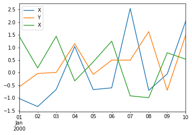

```python
#An example to demonstrate the plot()

import pandas as pd
import numpy as np

df = pd.DataFrame(np.random.randn(10,3),index=pd.date_range('1/1/2000',
   periods=10), columns=list('XYX'))

df.plot()
```

### Explanation

#### In the above example we have created a DataFrame using random number and plotted using plot()

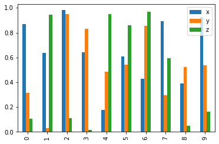

```python
#An example to demonstrate the BarPlot()

import pandas as pd
import numpy as np

df = pd.DataFrame(np.random.rand(10,3),columns=['x','y','z'])
df.plot.bar()
```

### Explanation

#### In the above example we have created a DataFrame with random number and plotted using plot.bar() function

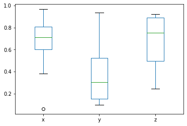

```python
#An example to demonstrate the Boxplot()

import pandas as pd
import numpy as np

df = pd.DataFrame(np.random.rand(10,3),columns=['x','y','z'])
df.plot.box()
```

### Explanation

#### In the above example we have created a DataFrame with random number and created a box plot using plot_box() function

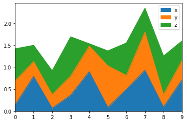

```python
#An example to demonstrate the Areaplot()

import pandas as pd
import numpy as np

df = pd.DataFrame(np.random.rand(10,3),columns=['x','y','z'])
df.plot.area()
```

### Explanation

#### In the above example we have created a DataFrame with random number and created a Area plot using plot_area() function

# References

## https://www.tutorialspoint.com/python_pandas